# Equivalent Kernel

# Setting up

First, load the necessary libraries:

```r
library(reticulate) # for R - Python usage
library(grf) # for the regression forest
library(np) # for kernel smoothing methods
```

```r
library(tidyverse)
library(foreach) # needed for faster implementation of my own NW-estimator
```

```r
library(doParallel) # needed for faster implementation of my own NW-estimator
```

```r
library(xgboost)
```

```r
source("xgboost_smoother.R")
```

Do the same for Python, the reticulate package usually runs stuff in a particular environment. In order to be safe and have all necessary packages installed, run this code:

```r
virtualenv_create("r-reticulate")
```

```
virtualenv: r-reticulate
```

```r
use_virtualenv("r-reticulate", required = TRUE)
py_config()
```

```
python:         /Users/henripfleiderer/.virtualenvs/r-reticulate/bin/python
libpython:      /opt/homebrew/opt/python@3.11/Frameworks/Python.framework/Versions/3.11/lib/python3.11/config-3.11-darwin/libpython3.11.dylib
pythonhome:     /Users/henripfleiderer/.virtualenvs/r-reticulate:/Users/henripfleiderer/.virtualenvs/r-reticulate
version:        3.11.6 (main, Oct  2 2023, 13:45:54) [Clang 15.0.0 (clang-1500.0.40.1)]
numpy:          /Users/henripfleiderer/.virtualenvs/r-reticulate/lib/python3.11/site-packages/numpy
numpy_version:  1.26.4

NOTE: Python version was forced by use_python() function
```

```r
#use_python("/Users/henripfleiderer/anaconda3/bin/python", required = TRUE)
virtualenv_install(packages = c("numpy==1.26.4","scipy", "scikit-learn","matplotlib","pandas"))
```

```
Using virtual environment '~/.virtualenvs/r-reticulate' ...
```

```
+ /Users/henripfleiderer/.virtualenvs/r-reticulate/bin/python -m pip install --upgrade --no-user 'numpy==1.26.4' scipy scikit-learn matplotlib pandas
```

```r
py_config()
```

```
python:         /Users/henripfleiderer/.virtualenvs/r-reticulate/bin/python
libpython:      /opt/homebrew/opt/python@3.11/Frameworks/Python.framework/Versions/3.11/lib/python3.11/config-3.11-darwin/libpython3.11.dylib
pythonhome:     /Users/henripfleiderer/.virtualenvs/r-reticulate:/Users/henripfleiderer/.virtualenvs/r-reticulate
version:        3.11.6 (main, Oct  2 2023, 13:45:54) [Clang 15.0.0 (clang-1500.0.40.1)]
numpy:          /Users/henripfleiderer/.virtualenvs/r-reticulate/lib/python3.11/site-packages/numpy
numpy_version:  1.26.4

NOTE: Python version was forced by use_python() function
```

Now, import the necessary python packages

```python
reticulate::repl_python()
import numpy as np

from sklearn.kernel_ridge import KernelRidge

from sklearn.metrics.pairwise import pairwise_kernels # to manually compute the kernel function

from sklearn.model_selection import GridSearchCV

from scipy import stats

import matplotlib.pyplot as plt

import pandas as pd

from sklearn.gaussian_process.kernels import RBF # matern kernel but for GP

from sklearn.gaussian_process.kernels import Matern # matern kernel but for GP

from sklearn.model_selection import RandomizedSearchCV

from scipy.stats import loguniform

from scipy.stats import uniform
```

# Functions for NW smooting in R:

Gaussian kernel, for two input vectors and one bandwidth, common across all dimensions:

```r
quit
gaussian_kernel = function(x1,x2,h, order = 2){

  x1 = matrix(x1,ncol = 1)
  x2 = matrix(x2,ncol = 1)

  d = dim(x1)[1]

  u = sqrt(t(x1-x2)%*%(x1-x2))/h

  const = (2*pi)^(1/2)

  if(order==2){
  k = exp(-u^2/2)/const
  } else if(order==4){
    k = (3/2 - 1/2*u^2)*exp(-u^2/2)/const
  } else if (order==6){
    k = (15/8 - 5/4*u^2 + 1/8 * u^4)*exp(-u^2/2)/const
  }

  return(k)
}
```

A function for fitting a NW-estimator. With given bandwidth. Uses parallel computing:

```r
fit_kern_Reg_parallel = function(x_test, x_train, y_train, h,...) {
  # Use foreach with .export to ensure functions are available in the parallel environment
  # Use foreach to parallelize the outer loop -> this makes it faster
  n = length(x_train[, 1])
  H_mat = foreach(i = seq_along(x_test[, 1]), .combine = "rbind", .packages = c("base"), .export = c("gaussian_kernel")) %dopar% {
    K_vec = numeric(n)

    # Inner loop
    for (j in seq_along(x_train[, 1])) {
      K_vec[j] = gaussian_kernel(x_test[i, ], x_train[j, ], h,...)
    }

    # Return row for H_mat
    K_vec / sum(K_vec)
  }

  fhat = H_mat%*%y_train

  results = list(
    predictions = fhat,
    H = H_mat
  )
  return(results)  # Return predictions
}
```

A function that computes the Generalized Cross-Validation (GCV) objective, also uses parallel computing. As proposed in Racine (2019):

```r
GCV_kern_smooth_parallel = function(x_train, y_train, h,...) {
  n = length(x_train[, 1])

  # Use foreach to parallelize the outer loop -> this makes it faster
  H_mat = foreach(i = seq_along(x_train[, 1]), .combine = "rbind", .packages = c("base"), .export = c("gaussian_kernel")) %dopar% {
    K_vec = numeric(n)

    # Inner loop
    for (j in seq_along(x_train[, 1])) {
      K_vec[j] = gaussian_kernel(x_train[i, ], x_train[j, ], h,...)
    }

    # Return row for H_mat
    K_vec / sum(K_vec)
  }

  # Compute trace and GCV
  trace = sum(diag(diag(n) - H_mat))
  GCV = (trace / n)^(-2) * (1 / n) * sum((y_train - H_mat %*% y_train)^2)

  return(GCV)
}
```

A function that trains the model (optimizes bandwidth) and gives predictions on test points:

```r
fit_kern_Reg_GCV_parallel = function(x_test,x_train,y_train,h_min=0.1,h_max = 2,...){
  # x_eval -> a n_test x d-dimensional matrix of points to evaluate the function:
  # x_train -> training points, x values
  # y_train -> training points, y values
  # h_min -> min value for bandwidth
  # h_max -> max value for bandwidth

  # set up parallelization:
  n_cores = detectCores() - 1

  # Set up parallel cluster
  cl = makeCluster(n_cores)
  registerDoParallel(cl)

  # first, find the optimal bandwidth:

  result = optimize(function(h) GCV_kern_smooth_parallel(x_train, y_train, h,...),
                    interval = c(h_min, h_max),
                    tol = 1e-3)

  # Extract optimal bandwidth
  optimal_h = result$minimum

  model_fit = fit_kern_Reg_parallel(x_test,x_train,y_train,optimal_h,...)
  fhat = model_fit$predictions
  optimal_H_mat = model_fit$H

  stopCluster(cl)
  result = list(
    predictions = fhat,
    h_opt = optimal_h,
    H_opt = optimal_H_mat
  )

  return(result)
}
```

# Smooth function

Create a multivariate smooth function to check the curse of dimensionality, for a sin function (nonlinear) with a polynomial inside:

```r
y_function_smooth = function(x,b){
  y = sin(x%*%b)  #+ cos(-x%*%b)
}
```

Draw and visualize a realization for $p = 1$:

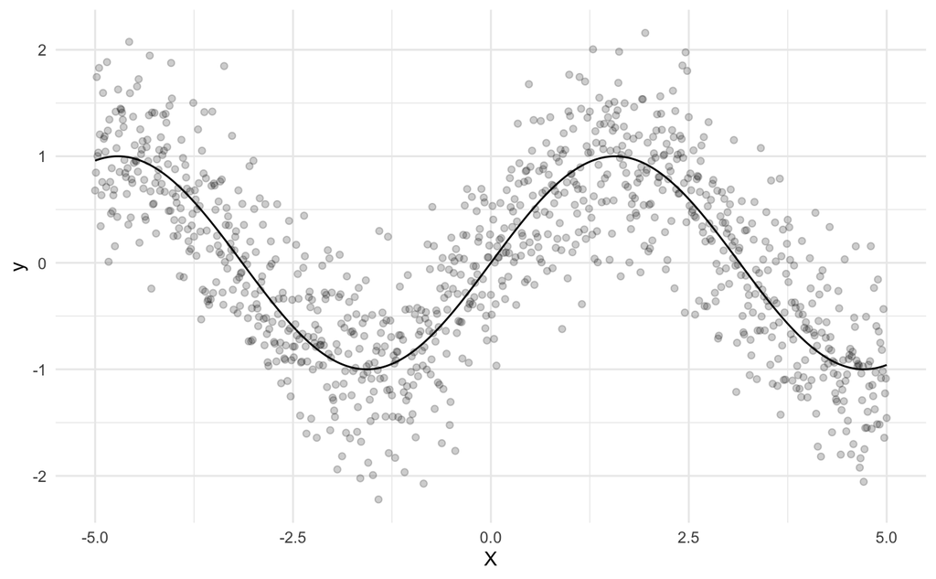

```r
set.seed(123)
p = 1
j = 1
b = rep(1,p)/((1:p)^j)
X = matrix(seq(-5,5,0.01),ncol = 1)
y = y_function_smooth(X,b) + rnorm(dim(X)[1],sd = 0.5)
y_true = y_function_smooth(X,b)
tibble(X,y) %>%
  ggplot(aes(x = X, y = y)) +
  geom_point(alpha = 0.2)+
  geom_line(aes(x = X, y = y_true), color = "black")+
  theme_minimal()
```

### KRR

##### Gaussian

Use KRR to find a prediction:

Grid for hyperparameter search:

```python
reticulate::repl_python()
param_distributions_Gaussian = {
  "alpha": uniform(1e-9, 1),
  "kernel__length_scale": uniform(1e-9, 8),
}

KRR_CV_Gaussian = RandomizedSearchCV(
    KernelRidge(kernel = RBF()),
    param_distributions=param_distributions_Gaussian,
    n_iter=500,
    n_jobs=-1
    )
```

Fit:

```python
_ = KRR_CV_Gaussian.fit(r.X,r.y) # fit the kernel ridge regression using cross.validated lambda
y_hat_CV = KRR_CV_Gaussian.predict(r.X) # predict the test observations
```

Plot true function, prediction and observations:

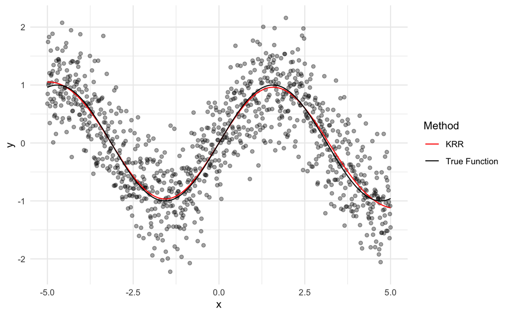

```r
quit
y_hat_KRR = as.numeric(py$y_hat_CV)
tibble(values = c(y_true, y_hat_KRR),
       x = rep(X,2),
       Method = factor(c(rep("True Function", length(y_true)),rep("KRR", length(y_hat_KRR)) ))) %>%
  ggplot(aes(x = x, y = values, color = Method)) +
  geom_point(aes(x = rep(X,2), y = rep(y,2)), alpha = 0.2, color = "black")+
  scale_color_manual(values = c("True Function" = "black", "KRR" = "red")) +
  geom_line()+
  labs(x = "x", y = "y")+
  theme_minimal()
```

```python
reticulate::repl_python()
K = RBF(length_scale = KRR_CV_Gaussian.best_params_['kernel__length_scale'],length_scale_bounds = "fixed")
K_mat = K(r.X)
inv = np.linalg.inv(K_mat + KRR_CV_Gaussian.best_params_['alpha']*np.eye(K_mat.shape[0]))
weight_matrix_Gaussian = K_mat@ inv # weight matrix
```

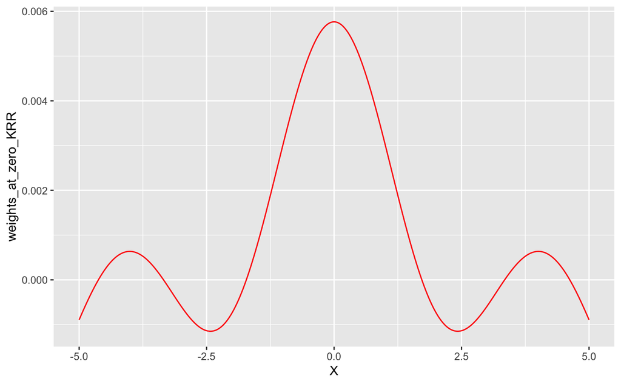

```r
quit
#which(X==0)
weights_at_zero_KRR = py$weight_matrix_Gaussian[which(X==0),]
tibble(X,weights_at_zero_KRR) %>%
  ggplot(aes(x = X, y = weights_at_zero_KRR)) +
  geom_line(color = "red")
```

### Regression Forest

Compare to Regression Forest:

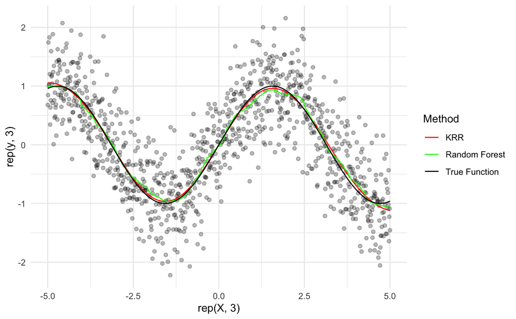

```r
reg_forest = regression_forest(X,y, tune.parameters = "all")
y_hat_rf = predict(reg_forest, X)$predictions

tibble(value = c(y_true,y_hat_KRR,y_hat_rf),
       X_grid = rep(X,3),
       Method = factor(c(rep("True Function", dim(X)[1]),rep("KRR", dim(X)[1]), rep("Random Forest", dim(X)[1])))) %>%
  ggplot(aes(x = rep(X,3), y = rep(y,3))) +
  geom_point(alpha = 0.1)+
  geom_line(aes(x = X_grid, y = value, color = Method))+
  scale_color_manual(values = c("True Function" = "black", "KRR" = "red", "Random Forest" = "green")) +
  theme_minimal()
```

Get the weights:

```r
weights_at_zero_RF = matrix(get_forest_weights(reg_forest,as.matrix(0)),ncol = 1)
```

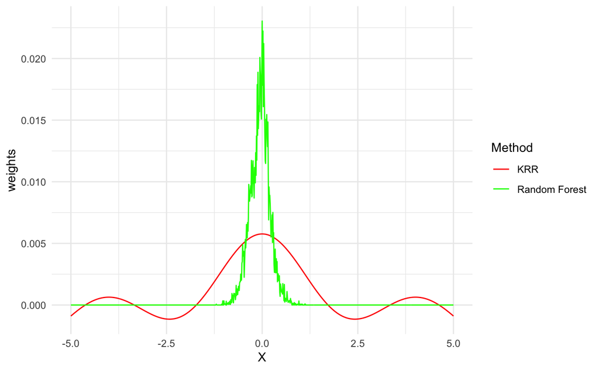

```r
tibble(weights = c(weights_at_zero_KRR,as.numeric(weights_at_zero_RF)),
        X = rep(X,2),
       Method = factor(c(rep("KRR", length(weights_at_zero_KRR)),rep("Random Forest", length(weights_at_zero_KRR))))) %>%
  ggplot(aes(x = X, y = weights, color = Method)) +
  geom_line()+
  scale_color_manual(values = c("KRR" = "red", "Random Forest" = "green")) +
  theme_minimal()
```

### Nadayara-Watson

##### Order 2

Now, additionally use NW:

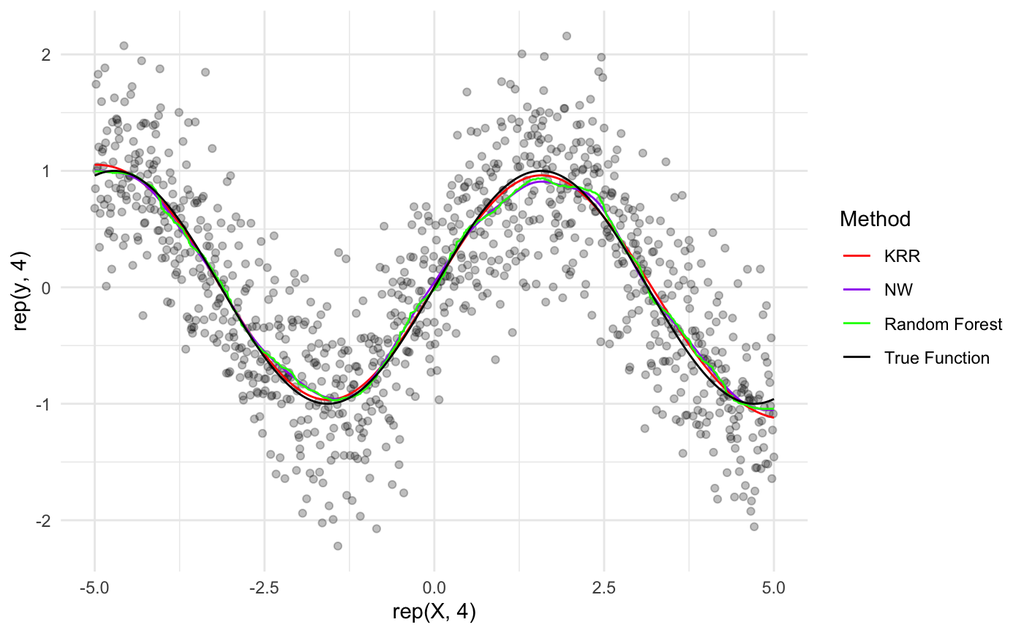

```r
fit_model = fit_kern_Reg_GCV_parallel(X,X,y,0.01,1)
y_hat_np = fit_model$predictions

tibble(value = c(y_true,y_hat_KRR,y_hat_rf,y_hat_np),
       X_grid = rep(X,4),
       Method = factor(c(rep("True Function", dim(X)[1]),rep("KRR", dim(X)[1]), rep("Random Forest", dim(X)[1]), rep("NW", dim(X)[1])    ))) %>%
  ggplot(aes(x = rep(X,4), y = rep(y,4))) +
  geom_point(alpha = 0.07)+
  geom_line(aes(x = X_grid, y = value, color = Method))+
  scale_color_manual(values = c("True Function" = "black", "KRR" = "red", "Random Forest" = "green", "NW" = "purple")) +
  theme_minimal()
```

Extract weights applied

```r
weights_at_zero_np = fit_model$H_opt[which(X==0),]
```

Plot “equivalent kernels”

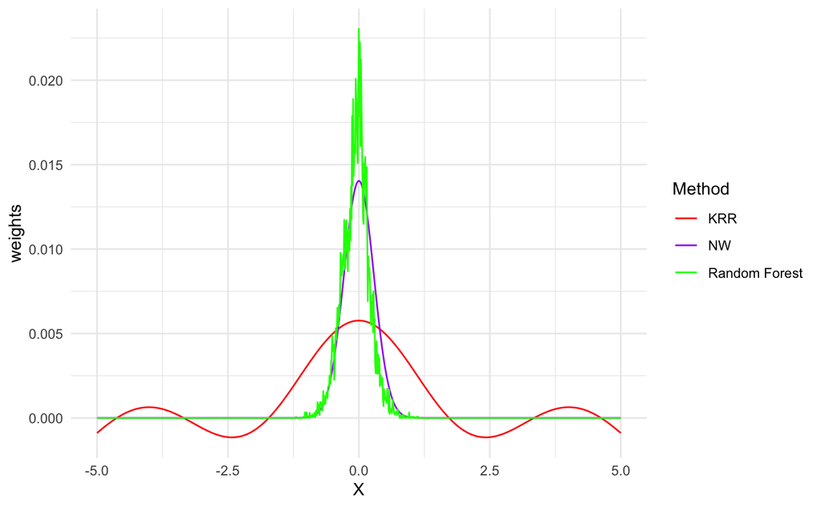

```r
tibble(weights = c(weights_at_zero_KRR,as.numeric(weights_at_zero_RF),weights_at_zero_np),
        X = rep(X,3),
       Method = factor(c(rep("KRR", length(weights_at_zero_KRR)),rep("Random Forest", length(weights_at_zero_KRR)),rep("NW", length(weights_at_zero_KRR))))) %>%
  ggplot(aes(x = X, y = weights, color = Method)) +
  geom_line()+
  scale_color_manual(values = c("KRR" = "red", "Random Forest" = "green", "NW" = "purple")) +
  theme_minimal()
```

### XG Boost

Set up:

```r
# Convert to DMatrix object
dtrain = xgb.DMatrix(data = as.matrix(X), label = y)
#dtest = xgb.DMatrix(data = as.matrix(test_features), label = test_targets)

# Define model parameters
params = list(
  booster = "gbtree",
  objective = "reg:squarederror",
  eta = 0.85, # Equivalent to learning_rate
  max_depth = 6, # Need to specify a value as XGBoost requires a numerical value
  min_child_weight = 100, # Not a direct equivalent but serves to control over-fitting
  subsample = 1,
  colsample_bytree = 1, # Equivalent to 'sqrt' in max_features
  # Note: XGBoost does not have a direct equivalent for 'max_leaf_nodes' and 'init'
  lambda = 100
)

# Number of boosting rounds (equivalent to n_estimators)
nrounds = 50

# Train the model
model = xgb.train(params = params, data = dtrain, nrounds = nrounds)
```

Get predictions and smoother matrix:

```r
leaf_indices_train = predict(model, dtrain, predleaf = TRUE)
smoother_train_XG = create_S_from_gbtregressor(model,leaf_indices_train,output_dir,save_output = FALSE)
```

Plot the prediction:

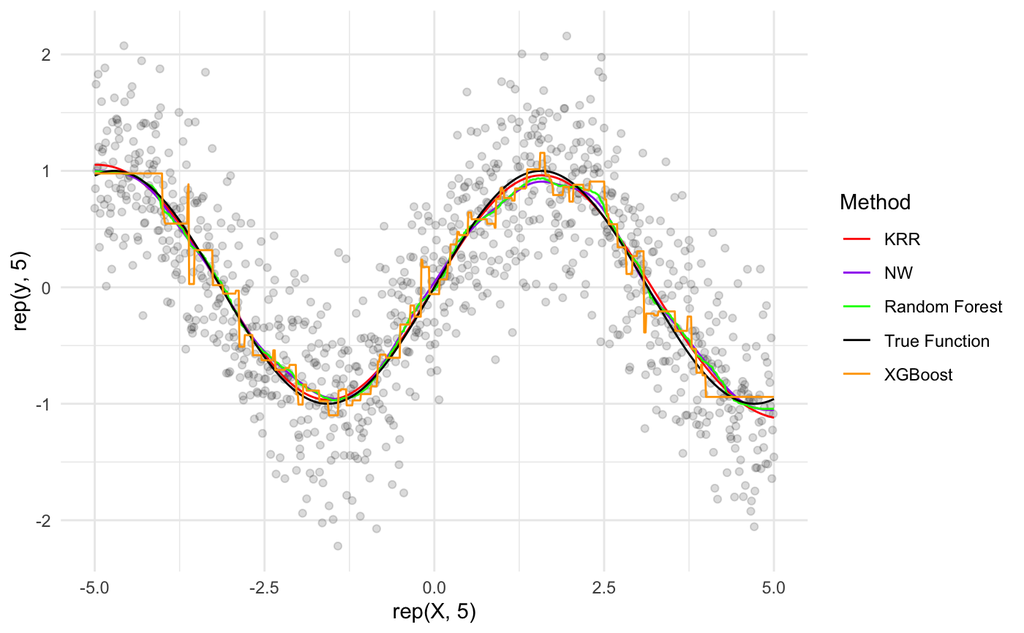

```r
y_hat_xg=predict(model, dtrain)

tibble(value = c(y_true,y_hat_KRR,y_hat_rf,y_hat_np,y_hat_xg),
       X_grid = rep(X,5),
       Method = factor(c(rep("True Function", dim(X)[1]),rep("KRR", dim(X)[1]), rep("Random Forest", dim(X)[1]), rep("NW", dim(X)[1]) , rep("XGBoost", dim(X)[1])    ))) %>%
  ggplot(aes(x = rep(X,5), y = rep(y,5))) +
  geom_point(alpha = 0.03)+
  geom_line(aes(x = X_grid, y = value, color = Method))+
  scale_color_manual(values = c("True Function" = "black", "KRR" = "red", "Random Forest" = "green", "NW" = "purple", "XGBoost" = "orange")) +
  theme_minimal()
```

Extract weights applied

```r
weights_at_zero_XG = smoother_train_XG[which(X==0),]
```

Plot “equivalent kernels”

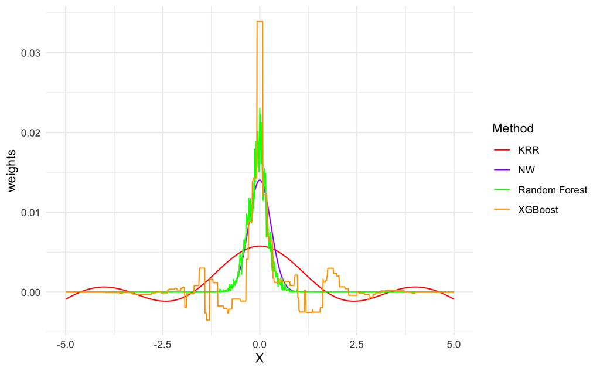

```r
tibble(weights = c(weights_at_zero_KRR,as.numeric(weights_at_zero_RF),weights_at_zero_np, weights_at_zero_XG),
        X = rep(X,4),
       Method = factor(c(rep("KRR", length(weights_at_zero_KRR)),rep("Random Forest", length(weights_at_zero_KRR)),rep("NW", length(weights_at_zero_KRR)),rep("XGBoost", length(weights_at_zero_KRR))))) %>%
  ggplot(aes(x = X, y = weights, color = Method)) +
  geom_line()+
  scale_color_manual(values = c("KRR" = "red", "Random Forest" = "green", "NW" = "purple", "XGBoost" = "orange")) +
  theme_minimal()
```

Sum the weights:

```r
sum(weights_at_zero_KRR)
```

```
[1] 1.000103
```

```r
sum(as.numeric(weights_at_zero_RF))
```

```
[1] 1
```

```r
sum(weights_at_zero_np)
```

```
[1] 1
```

```r
sum(weights_at_zero_XG)
```

```
[1] 0.9859045
```

# References

Racine, Jeffrey S. 2019. *An Introduction to the Advanced Theory and Practice of Nonparametric Econometrics: A Replicable Approach Using R*. Cambridge: Cambridge University Press. https://doi.org/10.1017/9781108649841.